# Mean value equality tests

data busteRs

season 2 / episode 15  
All rights reserved.  
Usage allowed only with the author's permission.  
Press `A` to turn slides into full text.  
Press `T` to show Table of Contents.

# What is this episode about?

When analyzing the data we often encounter a situation when we have two groups of measurements to compare and we are curious whether those groups are different.

In case of medical data it may be patients taking medication A and medication B, and the question which we may post is whether the effectiveness of both medications is comparable, or one of them is significantly better. By analyzing cultivation of cereals, we may have two varieties and want to see if one results in higher yields than the other. There is multitude of similar examples.

Usually, when we calculate a mean value of a certain characteristic in one group, and then a mean value of a certain characteristic in the other group, one of those mean values will be larger. But is it a significant difference?

For example, if I compare the average temperatures in Wrocław and average temperatures in Warsaw in the last 30 days, the average in Wroclaw is higher by about 0.5 degrees Celsius. However, is that difference a result of random fluctuations of temperature, or a reflection of a certain general regularity, that it is on average warmer in Wrocław?

Statistics are a response to similarly posed questions. By using such tools as tests for two samples we may help ourselves to answer the question whether the differences observed are coincidental or not.

In this episode, using data from IMDB (Internet Movie Database) website, we'll show how the procedure of testing the permutation test, a universal tool for comparing two groups, works.

# Movie and TV Series database

In the IMDB movie database (Internet Movie Database) one can find different data concerning TV series, in particular, the average user ratings issued for subsequent episodes of the series.

For example, on the http://www.imdb.com/title/tt0108778/epdate?ref_=ttep_ql_4 there are rating for *Friends* TV series, and on the http://www.imdb.com/title/tt0903747/epdate?ref_=ttep_ql_4 website, ratings for *Breaking Bad* series.

We have downloaded this data from the Internet, and prepared them so they would be available in a dataset `serialeIMDB` in a packet `PogromcyDanych`, which was attached to this course.

```r
library(PogromcyDanych)
head(serialeIMDB)
```

```
##   id       serial                         nazwa sezon odcinek ocena glosow
## 1  1 Breaking Bad                         Pilot     1       1   8.7   9357
## 2  2 Breaking Bad           Cat's in the Bag...     1       2   8.2   6506
## 3  3 Breaking Bad ...And the Bag's in the River     1       3   8.3   6176
## 4  4 Breaking Bad                    Cancer Man     1       4   7.9   5796
## 5  5 Breaking Bad                   Gray Matter     1       5   7.9   5664
## 6  6 Breaking Bad      Crazy Handful of Nothin'     1       6   8.7   6521
##      imdbId
## 1 tt0903747
## 2 tt0903747
## 3 tt0903747
## 4 tt0903747
## 5 tt0903747
## 6 tt0903747
```

# Is Friends series better than Breaking Bad series?

With the data set series, we can compare the episode ratings of the two series.

For starters let's draw two subsets from the entire TV series data set, separately ratings for the *Friends* series and ratings for the *Breaking Bad* series

```r
# oceny dla serialu Friends
ocenyFriends     <- serialeIMDB[serialeIMDB$serial == "Friends", "ocena"]
summary(ocenyFriends)
```

```
##    Min. 1st Qu.  Median    Mean 3rd Qu.    Max.
##   7.400   8.300   8.500   8.508   8.700   9.600
```

```r
# oceny dla serialu Breaking Bad
ocenyBreakingBad <- serialeIMDB[serialeIMDB$serial == "Breaking Bad", "ocena"]
summary(ocenyBreakingBad)
```

```
##    Min. 1st Qu.  Median    Mean 3rd Qu.    Max.
##   7.400   8.025   8.400   8.481   8.800  10.000
```

Mean value for one series is `8.508`, and for the other `8.481`.

Is it a large or small difference?

# Graphic comparison

Is the observed difference large, and is it significant?

# Mean values testing - algorithm

Statisticians have developed a number of tests aimed at comparing values from two groups. In most cases those tests provide us with similar results, so instead of presenting a lexicon of them, we'll use one example to clarify how the testing works. We'll present so called permutation test for mean values comparison.

Idea for comparing two groups consists of three steps. We'll present them one by one.

### Step 1: Formulate a hypothesis, specify what do you want to compare

We'll be testing hypothesis (=assumption), whether values in one set are significantly larger than in the other set.

Let's formulate this hypothesis as follows: *Is the observed difference between mean values large enough to consider it a significant one?*

### Step 2: Specify the difference value measure

Let's assume that the value of differences between groups will be measured with the absolute value of the difference between mean values of both groups.

```r
mean(ocenyBreakingBad)
```

```
## [1] 8.480645
```

```r
mean(ocenyFriends)
```

```
## [1] 8.507983
```

```r
# moduł różnicy średnich
(obserwowana_roznica <- abs(mean(ocenyBreakingBad) - mean(ocenyFriends)))
```

```
## [1] 0.02733803
```

# Mean values testing - algorithm

### Step 3: Compare the observed value of the difference with a situation where the groups are not different

But how can we know what the differences would be if the groups were not different. We can estimate in as follows

- [I] We'll randomly mix the values in both groups, maintaining the size of the groups. Thus we will get two groups about which we know that they are not significantly different, and the only differences are a result of random fluctuations,
- [II] We'll calculate how large is the difference for newly created groups,
- [III] We'll repeat steps [I] and [II] multiple times (e.g. 99999 times) to check how large are the values which can be assumed by the difference, when both groups are not different from each other.

This calculation of differences on samples differing only by random fluctuation is executed by the following code.

```r
# połączony wektor ocen z obu seriali
ocenyRazem <- c(ocenyFriends, ocenyBreakingBad)
# ile pierwszych ocen pochodzi z Friends
liczbaFriends <- length(ocenyFriends)
# wynikiem funkcji replicate będzie 99999 wartości, modułów różnic średnich po wymieszaniu obserwacji pomiędzy grupami
roznice <- replicate(99999, {
  # wymieszaj losowo wartości pomiędzy grupami
  wymieszane <- sample(ocenyRazem)
  # losowo dobrane próby, pierwsze 'liczbaFriends' wartości to grupa pierwsza, reszta to druga
  oceny1 <- wymieszane[1:liczbaFriends]
  oceny2 <- wymieszane[-(1:liczbaFriends)]
  # różnica pomiedzy losowymi grupami
  abs(mean(oceny1) - mean(oceny2))
})
# jedną z permutacji jest brak permutacji, dodajemy więc obserwowaną różnicę
roznice <- c(roznice, obserwowana_roznica)
# wyświetl 20 różnic zaobserowanych w przypadku losowego podziału na grupy
head(roznice,20)
```

```
##  [1] 0.011073462 0.092396313 0.060084034 0.035470317 0.013106533
##  [6] 0.027554893 0.021238818 0.029587964 0.074315533 0.088330171
## [11] 0.045852535 0.045852535 0.025521822 0.059867173 0.133274600
## [16] 0.002941176 0.023271889 0.055801030 0.013106533 0.011290323
```

# Is Friends series better than Breaking Bad series?

Now we can compare `obserwowana_roznica` value with a value vector `roznice`.

The `roznice` vector describes what differences can we expect when the samples vary only by random fluctuations. If the `obserwowana_roznica` was significantly greater than the value of the differences vector, it would be a strong argument that the difference in mean values is not coincidental.

On the plot, let's compare the difference values for random fluctuations (in gray) with the observed difference (in red).

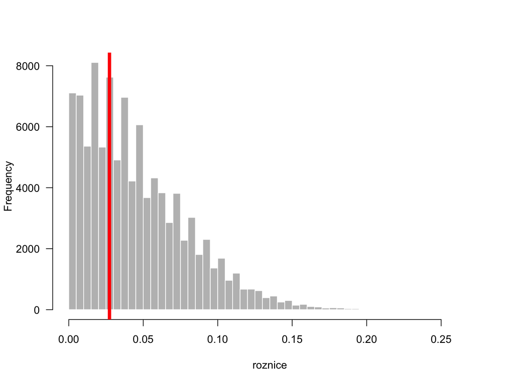

```r
# wektor referencyjnych różnic po losowym podziale na grupy
hist(roznice, 50, col="grey", main="", las=1, border="white")
# obserowana różnica w średnich pomiędzy Friends a Breaking Bad
abline(v=obserwowana_roznica, col="red", lwd=5)
```

# Is Friends series better than Breaking Bad series? - p-value

The plot assists in understanding how the observed mean values difference varies from those generated by random fluctuations.

However, to make a decision it is better to have one number. Let's calculate what proportion of the differences for random fluctuation is greater or equal to the observed difference. Such frequency is called p-value.

```r
# p-wartość
mean(roznice >= obserwowana_roznica)
```

```
## [1] 0.64452
```

When samples are randomly mixed, and therefore their mean values are theoretically equal. Knowing that by random fluctuations, in as much as 64% instances, we observe bigger difference than that between *Friends* and *Breaking Bad*, will we assume that the difference between two series is significant?

Probably not. Although the threshold we assume depends on the intended use, it is often assumed as 0.05. For historical reasons.

In any case, if the p-value obtained is less than 0.05, then we assume that the observed value is significantly different from coincidental (=0). If the obtained p-value is larger or equal to 0.05, we assume that there are no statistically significant differences.

In case of Friends and Breaking Bad, this difference was small and insignificant.

# Is Friends series better than Sherlock series?

Let's compare two different series now.

# Is Friends series better than Sherlock series?

```r
ocenyFriends     <- serialeIMDB[serialeIMDB$serial == "Friends", "ocena"]
ocenySherlock    <- serialeIMDB[serialeIMDB$serial == "Sherlock", "ocena"]
# moduł różnicy średnich
(obserwowana_roznica <- abs(mean(ocenyFriends) - mean(ocenySherlock)))
```

```
## [1] 0.4647441
```

Let's repeat the permutation test for those two series. This time the difference observed is larger than practically all values generated by the permutation test.

```r
# połączony wektor ocen z obu seriali
ocenyRazem <- c(ocenyFriends, ocenySherlock)
# ile pierwszych ocen pochodzi z Friends
liczbaFriends <- length(ocenyFriends)
# permutacyjny test
liczbaFriends <- length(ocenyFriends)
roznice <- replicate(99999, {
  wymieszane <- sample(ocenyRazem)
  oceny1 <- wymieszane[1:liczbaFriends]
  oceny2 <- wymieszane[-(1:liczbaFriends)]
  # różnica pomiedzy losowymi grupami
  abs(mean(oceny1) - mean(oceny2))
})
# dodajemy obserowaną różnicę
roznice <- c(roznice, obserwowana_roznica)
```

# Is Friends series better than Sherlock series? - p-value

Having calculated differences for random fluctuations, we can compare them graphically with mean value difference for Sherlock and Friends.

This time the p-value is very small, observed mean values difference between the series is significantly larger than those, which are presented for random division into groups.

Thus we assume that Sherlock has significantly higher mean value of ratings than Friends.

```r
# p-wartość dla różnicy średnich
mean(roznice >= obserwowana_roznica)
```

```
## [1] 9e-05
```

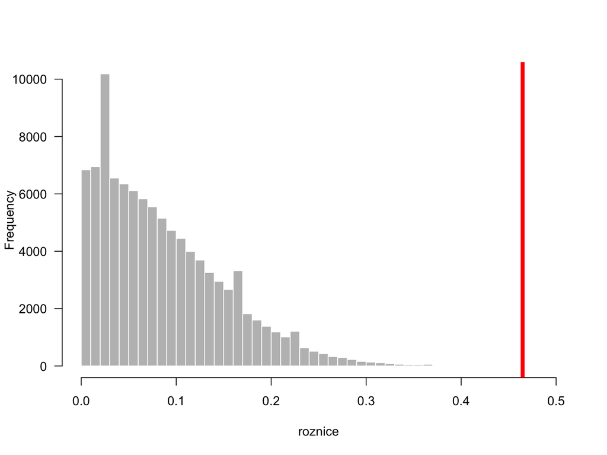

```r
# wektor referencyjnych różnic po losowym podziale na grupy
hist(roznice, 50, col="grey", main="", las=1, border="white", xlim=c(0,0.5))
# obserwowana różnica w średnich pomiędzy Friends a Sherlock
abline(v=obserwowana_roznica, col="red", lwd=5)
```

# Which two series are significantly different?

Using the application below you can compare two series and assess whether the difference is statistically significantly different.

[interactive chart not shown]

# Tasks

- Find two TV series (other than Friends and Sherlock), which are significantly different, assuming 0.05 as the significance threshold.
- Find two TV series (other than Friends and Breaking Bad), which are not significantly different, assuming 0.05 as the significance threshold.